# Transformation of Microfinance Institutions and Financial Inclusion in Africa

NGOs have the highest median gross loans, which is surprising given their relatively smaller size. On the other hand, banks and rural banks, respectively have the lowest gross loans to assets meaning they are less efficient in converting their assets into credit (Figure 2- Panel 4). Again, it goes to show, at least in the case of Africa that breadth and depth of financial outreach are not always mutually exclusive. In this case, NGOs are able to reach the poorest borrowers, going by the percent of female borrowers and average loan balance per borrower, while at the same time reaching a wide customer base as indicated by the gross loans to assets. The evidence so far leans towards the welfare approach where profitability is incompatible with outreach to the financially excluded.

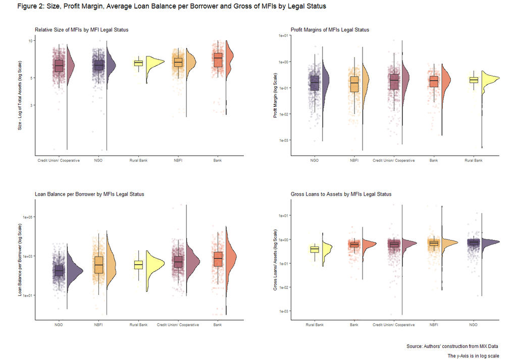

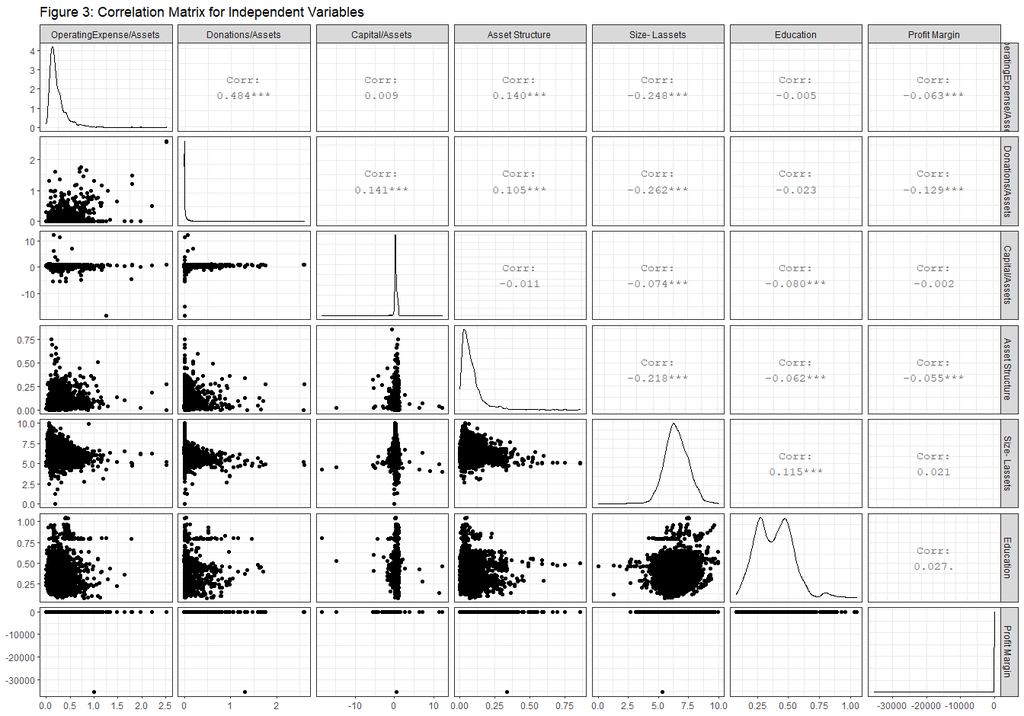

## Trends in Dependent and Independent Variables

Figure 4 below shows the trends over time for donations, capital, profits and operating expense to assets ratio. Figure 4 (Panel A) shows that median donations to assets ratio has been on a downward spiral for the period 1999-2019. The observation confirms the neo-liberal shift where donors expect MFIs to be more financially self-sustainable. The trend is expected given the abundance of literature on the conversion of MFIs from NGOs to the commercial model, and the subsequent drop in donor funding.

We turn to Figure 5 which shows a rise in MFI size, average loan balance per borrower, and gross loans to total assets, while the percent of female borrowers is on a downward trend. The rise in the average loans balance per borrower and the concomitant drop in the proportion of female borrowers indicates a consistent drop in the outreach of MFIs to the financially excluded as MFIs rely less on donations and more on commercial capital. It further shows the effects of the neo-liberal, for-profit paradigm which may hurt the social performance of MFIs, specifically the depth of outreach. However, it appears the breadth of outreach is getting better with time as MFIs give more loans. Taken together, it implies that MFIs give larger loans to less financially excluded people in a bid to make ample financial return to allow for financial sustainability and pay dividends and interest to investors.

## **Descriptive Statistics**

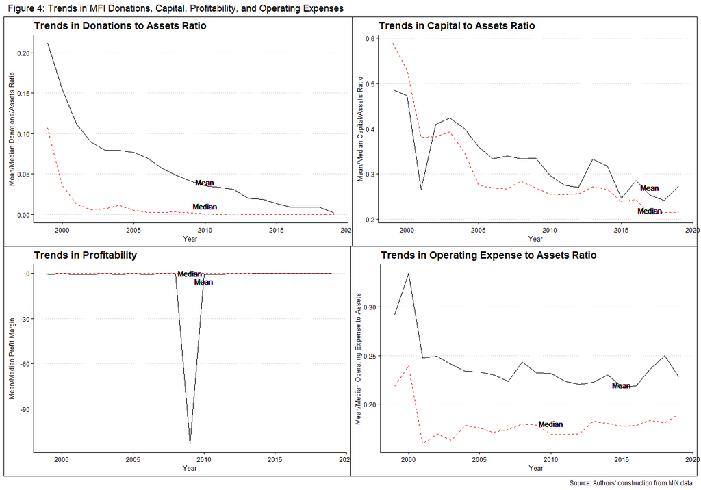

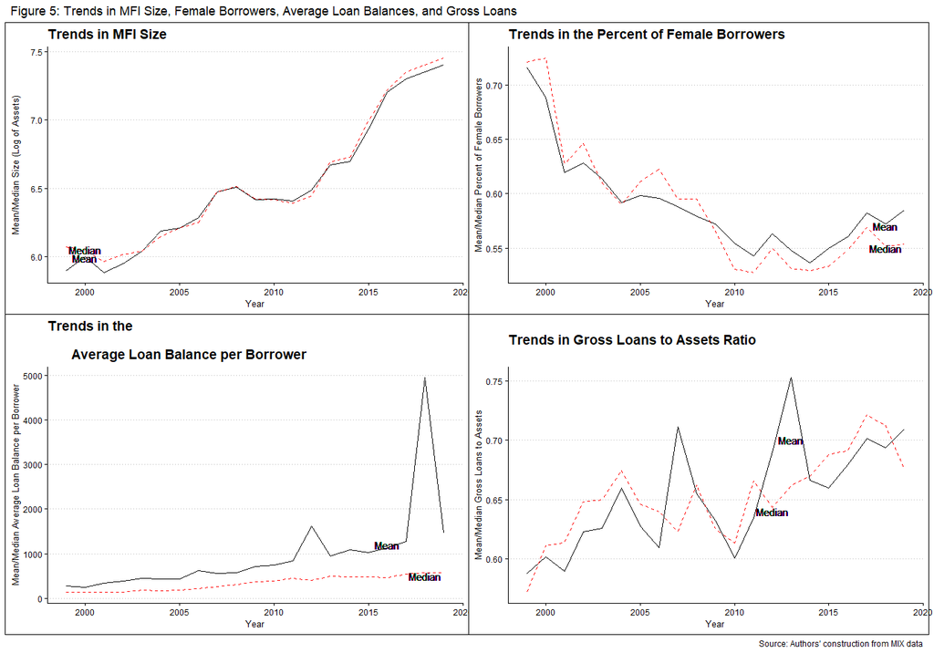

Summary Statistics for Categrical Independent Variables

| Variable | Completeness | Counts |
| --- | --- | --- |
| currentlegalstatus | 1 | Cre: 1427, NBF: 1318, NGO: 1280, Ban: 619 |
| age | 1 | Mat: 2558, New: 1200, You: 1024 |

Summary Statistics for Dependent Variables

| Variable | currentlegalstatus | Mean | SD | Min | Q1 | Median | Q3 | Max |
| --- | --- | --- | --- | --- | --- | --- | --- | --- |
| percent_of_female_borrowers | NGO | 0.73 | 0.23 | 0.00 | 0.60 | 0.77 | 0.94 | 1.00e+00 |
| percent_of_female_borrowers | Bank | 0.52 | 0.20 | 0.04 | 0.37 | 0.52 | 0.60 | 1.00e+00 |
| percent_of_female_borrowers | NBFI | 0.56 | 0.23 | 0.00 | 0.40 | 0.55 | 0.72 | 1.00e+00 |
| percent_of_female_borrowers | Credit Union/ Cooperative | 0.46 | 0.24 | 0.00 | 0.28 | 0.43 | 0.61 | 1.00e+00 |
| percent_of_female_borrowers | Rural Bank | 0.50 | 0.19 | 0.13 | 0.37 | 0.50 | 0.60 | 1.00e+00 |
| average_loan_balance_per_borrower | NGO | 286.23 | 391.15 | 0.00 | 96.00 | 174.00 | 316.00 | 4.19e+03 |
| average_loan_balance_per_borrower | Bank | 1573.01 | 2801.56 | 0.00 | 275.25 | 712.50 | 1584.00 | 3.40e+04 |
| average_loan_balance_per_borrower | NBFI | 819.69 | 1443.97 | 0.00 | 130.75 | 338.00 | 897.25 | 1.99e+04 |
| average_loan_balance_per_borrower | Credit Union/ Cooperative | 1316.29 | 13562.13 | 0.00 | 250.75 | 490.50 | 933.25 | 4.01e+05 |
| average_loan_balance_per_borrower | Rural Bank | 410.19 | 302.19 | 15.00 | 210.00 | 351.00 | 561.00 | 1.88e+03 |
| gross_loan_portfolio_to_total_assets | NGO | 0.72 | 0.43 | 0.00 | 0.59 | 0.72 | 0.83 | 1.22e+01 |
| gross_loan_portfolio_to_total_assets | Bank | 0.57 | 0.27 | 0.00 | 0.45 | 0.58 | 0.70 | 3.28e+00 |
| gross_loan_portfolio_to_total_assets | NBFI | 0.71 | 0.99 | 0.00 | 0.55 | 0.69 | 0.81 | 2.50e+01 |
| gross_loan_portfolio_to_total_assets | Credit Union/ Cooperative | 0.61 | 0.76 | 0.00 | 0.47 | 0.62 | 0.73 | 2.74e+01 |
| gross_loan_portfolio_to_total_assets | Rural Bank | 0.40 | 0.23 | 0.07 | 0.28 | 0.39 | 0.50 | 1.87e+00 |

Summary Statistics for Continous Independent Variables

| Variable | currentlegalstatus | Mean | SD | Min | Q1 | Median | Q3 | Max |
| --- | --- | --- | --- | --- | --- | --- | --- | --- |
| operating_expense_assets | NGO | 0.29 | 0.24 | 0.00 | 0.15 | 0.23 | 0.37 | 2.52 |
| operating_expense_assets | Bank | 0.23 | 0.16 | 0.02 | 0.12 | 0.20 | 0.30 | 2.21 |
| operating_expense_assets | NBFI | 0.26 | 0.21 | 0.00 | 0.13 | 0.20 | 0.31 | 1.98 |
| operating_expense_assets | Credit Union/ Cooperative | 0.16 | 0.11 | 0.00 | 0.10 | 0.13 | 0.18 | 1.19 |
| operating_expense_assets | Rural Bank | 0.15 | 0.04 | 0.08 | 0.12 | 0.14 | 0.17 | 0.25 |
| donations_assets_ratio | NGO | 0.10 | 0.23 | 0.00 | 0.00 | 0.01 | 0.09 | 2.60 |
| donations_assets_ratio | Bank | 0.02 | 0.09 | 0.00 | 0.00 | 0.00 | 0.00 | 1.30 |
| donations_assets_ratio | NBFI | 0.04 | 0.13 | 0.00 | 0.00 | 0.00 | 0.02 | 1.71 |
| donations_assets_ratio | Credit Union/ Cooperative | 0.02 | 0.08 | 0.00 | 0.00 | 0.00 | 0.01 | 1.62 |
| donations_assets_ratio | Rural Bank | 0.00 | 0.01 | 0.00 | 0.00 | 0.00 | 0.00 | 0.08 |
| capital_asset_ratio | NGO | 0.42 | 0.76 | -18.35 | 0.22 | 0.38 | 0.64 | 12.15 |
| capital_asset_ratio | Bank | 0.31 | 0.23 | -0.57 | 0.15 | 0.24 | 0.39 | 1.70 |
| capital_asset_ratio | NBFI | 0.39 | 0.48 | -1.78 | 0.18 | 0.32 | 0.57 | 9.05 |
| capital_asset_ratio | Credit Union/ Cooperative | 0.20 | 0.67 | -14.82 | 0.11 | 0.21 | 0.36 | 11.27 |
| capital_asset_ratio | Rural Bank | 0.18 | 0.24 | -0.13 | 0.10 | 0.14 | 0.16 | 1.98 |
| asset_structure | NGO | 0.08 | 0.08 | 0.00 | 0.03 | 0.06 | 0.10 | 0.75 |
| asset_structure | Bank | 0.08 | 0.09 | 0.00 | 0.03 | 0.06 | 0.10 | 0.86 |
| asset_structure | NBFI | 0.07 | 0.07 | 0.00 | 0.03 | 0.05 | 0.09 | 0.55 |
| asset_structure | Credit Union/ Cooperative | 0.08 | 0.07 | 0.00 | 0.04 | 0.07 | 0.11 | 0.60 |
| asset_structure | Rural Bank | 0.06 | 0.04 | 0.00 | 0.03 | 0.04 | 0.07 | 0.21 |
| lassets | NGO | 6.31 | 0.93 | 0.00 | 5.76 | 6.29 | 6.87 | 9.93 |
| lassets | Bank | 7.07 | 1.24 | 2.50 | 6.08 | 7.19 | 7.89 | 9.98 |
| lassets | NBFI | 6.62 | 0.82 | 2.39 | 6.13 | 6.64 | 7.19 | 8.68 |
| lassets | Credit Union/ Cooperative | 6.28 | 0.98 | 1.30 | 5.58 | 6.21 | 6.93 | 9.33 |
| lassets | Rural Bank | 6.52 | 0.55 | 4.48 | 6.25 | 6.61 | 6.86 | 7.43 |
| education | NGO | 0.42 | 0.16 | 0.07 | 0.29 | 0.42 | 0.50 | 1.05 |
| education | Bank | 0.41 | 0.15 | 0.08 | 0.28 | 0.46 | 0.51 | 0.96 |
| education | NBFI | 0.38 | 0.14 | 0.10 | 0.26 | 0.36 | 0.48 | 0.96 |
| education | Credit Union/ Cooperative | 0.34 | 0.12 | 0.12 | 0.25 | 0.31 | 0.44 | 0.60 |
| education | Rural Bank | 0.48 | 0.04 | 0.46 | 0.46 | 0.47 | 0.49 | 0.69 |
| profit_margin | NGO | -0.51 | 3.43 | -49.12 | -0.30 | 0.03 | 0.17 | 3.62 |
| profit_margin | Bank | -70.78 | 1584.24 | -35495.62 | -0.07 | 0.11 | 0.23 | 0.81 |
| profit_margin | NBFI | -0.36 | 1.99 | -45.36 | -0.26 | 0.04 | 0.18 | 3.56 |
| profit_margin | Credit Union/ Cooperative | -0.35 | 2.36 | -50.43 | -0.23 | 0.05 | 0.21 | 6.20 |
| profit_margin | Rural Bank | 0.16 | 0.23 | -1.89 | 0.14 | 0.19 | 0.25 | 0.43 |

## **Regression Analysis**

### *Percent of Women Borrowers*

The results gain more credence when we examine operating expenses to assets ratio. There is a positive and significant relationship between operating expense to assets ratio on the one hand and percent of women borrowers on the other. It means that an MFI has to spend more to reach financially excluded clients, which in turn means fewer profits at a given level of revenue. As expected, the conversion of MFIs from NGOs to the commercial model could lead to a reduction in operating expenses in the quest for profits in line with the profit incentive arising from the agency theory (Eisenhardt 1989).

Hence, it follows that a quest for profit is bad for financial inclusion by causing mission drift in line with prior research (Wagenaar 2012; P. W. Roberts 2013; Lopatta and Tchikov 2016; Mia and Lee 2017). Except in the unlikely scenario where MFIs generate profits by raising revenue without lowering costs, Africa should rethink the case for transformation of MFIs. Indeed profitability has a positive relationship albeit insignificant effects on the percent of women borrowers. With this hindsight it would appear like the viable explanation for the profitability-operating expense-financial inclusion issue is that for commercial MFIs, a reduction in operating expenses in the short run is warranted if this translates into higher profits that allow the MFIs to reach more financially excluded clients while cross subsidizing them in the median and long term. However, (D’Espallier et al. 2017) note that for transformed MFIs, profits tend to drop in the short term but not necessarily in the long term, although operating expenses generally drop.The drop in profitability is driven by transformed MFIs charging lower interest rates, a contentious issue in micro-finance. It would be interesting to examine the dynamics between profitability, operating expense and financial inclusion for MFIs over a longer period.

The significant control variables are education and region. Education varies positively with outreach to women as does region. A country in Northern Africa has lower outreach to women than an otherwise similar country in Sub-Sahara Africa which could be due to religious beliefs that harm financial inclusion for women (Hassan, Hossain, and Unsal 2018). It is notable that North Africa has only NGOs in the sample meaning that cultural and religious inclinations play a bigger role in driving financial inclusion than the operating model of MFIs. Education also appears to play a key role in financial inclusion arising from its empowerment in terms of women joining the formal labour market and financial literacy that allows for better financial decision making (Zins and Weill 2016; Chikalipah 2017).

`Fixed Effects Regressions- Standard errors in brackets(***1%, **5%, *10%)`

[output not shown]

`Random Effects and Pooled OLS Regressions- Standard errors in brackets(***1%, **5%, *10%)`

| Variables | Percent_female | Percent_female | Average_loan | Average_loan | Gross_loans | Gross_loans |
| --- | --- | --- | --- | --- | --- | --- |
|  | Random_Effects | Pooled_OLS | Random_Effects | Pooled_OLS | Random_Effects | Pooled_OLS |
|  | (1) | (2) | (3) | (4) | (5) | (6) |
| Bank | -0.214*** | -0.182*** | 276.000 | 276.000 | -0.013 | -0.061 |
|  | (0.044) | (0.043) | (585.000) | (585.000) | (0.053) | (0.046) |
| NBFI | -0.181*** | -0.178*** | 152.000 | 152.000 | 0.027 | -0.008 |
|  | (0.030) | (0.029) | (379.000) | (379.000) | (0.038) | (0.034) |
| Credit Union | -0.260*** | -0.236*** | 872.000** | 872.000** | 0.088** | 0.043 |
|  | (0.030) | (0.030) | (388.000) | (388.000) | (0.039) | (0.035) |
| Rural Bank | -0.241*** | -0.214*** | 112.000 | 112.000 | -0.119 | -0.185** |
|  | (0.061) | (0.050) | (570.000) | (570.000) | (0.078) | (0.073) |
| Age: Young | -0.010 | -0.011 | -314.000 | -314.000 | 0.077*** | 0.049* |
|  | (0.012) | (0.017) | (305.000) | (305.000) | (0.028) | (0.029) |
| Age: Mature | -0.010 | -0.024 | -641.000* | -641.000* | 0.117*** | 0.077** |
|  | (0.017) | (0.023) | (340.000) | (340.000) | (0.030) | (0.031) |
| Region:Africa | 0.098* | 0.088 | 456.000 | 456.000 | -0.060 | -0.034 |
|  | (0.054) | (0.059) | (650.000) | (650.000) | (0.081) | (0.068) |
| Op exp/assets | 0.098*** | 0.295*** | 403.000 | 403.000 | 0.208*** | 0.121 |
|  | (0.034) | (0.062) | (1,083.000) | (1,083.000) | (0.070) | (0.076) |
| Donations/assets | -0.007 | 0.028 | 374.000 | 374.000 | -0.383*** | -0.474*** |
|  | (0.032) | (0.053) | (619.000) | (619.000) | (0.094) | (0.099) |
| Capital/asset | 0.002 | 0.048*** | 95.400 | 95.400 | 0.924*** | 0.777*** |
|  | (0.007) | (0.015) | (154.000) | (154.000) | (0.029) | (0.028) |
| Asset_structure | 0.035 | -0.168 | 1,901.000 | 1,901.000 | -0.787*** | -0.828*** |
|  | (0.077) | (0.131) | (1,387.000) | (1,387.000) | (0.164) | (0.168) |
| Size(Lassets) | -0.001 | -0.022 | 1,013.000*** | 1,013.000*** | -0.024 | -0.005 |
|  | (0.011) | (0.014) | (197.000) | (197.000) | (0.017) | (0.017) |
| Education | 0.188*** | 0.172** | 305.000 | 305.000 | 0.115 | 0.128 |
|  | (0.071) | (0.079) | (962.000) | (962.000) | (0.094) | (0.089) |
| Profit_margin | 0.002 | 0.001 | -31.200 | -31.200 | 0.011*** | 0.008** |
|  | (0.002) | (0.003) | (20.800) | (20.800) | (0.003) | (0.004) |
| r.squared | 0.111 | 0.288 | 0.026 | 0.026 | 0.472 | 0.413 |
| adj.r.squared | 0.101 | 0.280 | 0.0161 | 0.0161 | 0.467 | 0.407 |
| statistic | 273*** | 38.1*** | 89.4*** | 2.63*** | 3017.027*** | 71.499*** |
| nobs | 3240 | 3240 | 3380 | 3380 | 3497 | 3497 |